# TRGAted App: Use your own sample list

Nick Borcherding

6/1/2018

# Set Up

The goal of this tutorial is to demonstrate how to parse through the TRGAted application data based on your personal groupings. This tutorial will principally cover the basics of a categorical survival comparison based on your groupings and a continuous survival comparison based on your groupings. The tutorial is concerned with parsing through the sample information in one of the cancer types available through the TRGAted app.

### Load Libraries

```r
library(dplyr)
library(stringr)
library(survival)
library(survminer)
```

### Load Sample Groupings

```r
#Samplist format: two columns, col 1 - IDs, col 2 - group
#Sample ID format: TCGA-XX-XXXX-XX
#Patient ID format: TCGA-XX-XXXX (this is what is used in the TRGAted APP)
#Sample IDs have to be of primary tumors (ending with -01), if unsure of the sample information, run the filter to remove none -01 IDs.
samplelist <- read.delim("~/samplelist.txt")
colnames(samplelist) <- c("ID", "group")
head(samplelist)
```

```
##                ID group
## 1 TCGA-A2-A0YM-01 Basal
## 2 TCGA-D8-A1XQ-01 Basal
## 3 TCGA-B6-A0IJ-01 Basal
## 4 TCGA-E9-A22G-01 Basal
## 5 TCGA-E9-A1N8-01 Basal
## 6 TCGA-BH-A0WA-01 Basal
```

### Processing the samplelist

TRGAted application runs on Patient ID, we need to filter for sample IDs containing -01 (primary tumor) and then remove the -01 from the ID to convert to Patient ID.

```r
samplelist <- dplyr::filter(samplelist, grepl("-01",ID)) #For Sample IDs to remove -01
samplelist$ID <- substr(samplelist$ID,1,nchar(as.character(samplelist$ID))-3) #For Sample IDs to remove characters after the hyphen to convert them to Patient ID
samplelist<- samplelist[order(samplelist$ID),] #Alphabetically orders data frame by Patient ID
head(samplelist)
```

```
##               ID group
## 94  TCGA-A1-A0SK Basal
## 67  TCGA-A1-A0SO Basal
## 122 TCGA-A1-A0SP Basal
## 17  TCGA-A2-A04P Basal
## 80  TCGA-A2-A04Q Basal
## 125 TCGA-A2-A04T Basal
```

### Load Cancer Data

This could be any .csv file located in the TRGAted github repository.

```r
cancerType <- read.csv("~/TRGAted/BRCA.csv")
cancerType <- cancerType[cancerType$patient %in% samplelist$ID,] #list removes samples not in the samplelist
cancerType <- merge(samplelist, cancerType, by.x="ID", by.y = "patient") #merges your list with the TRGAted App Data
```

# Analysis

### Survival analysis based on categorical groupings

Here we are going to examine the difference in overall survival outcomes based on the HER2 versus basal (or basal-like) subtypes of breast cancer.

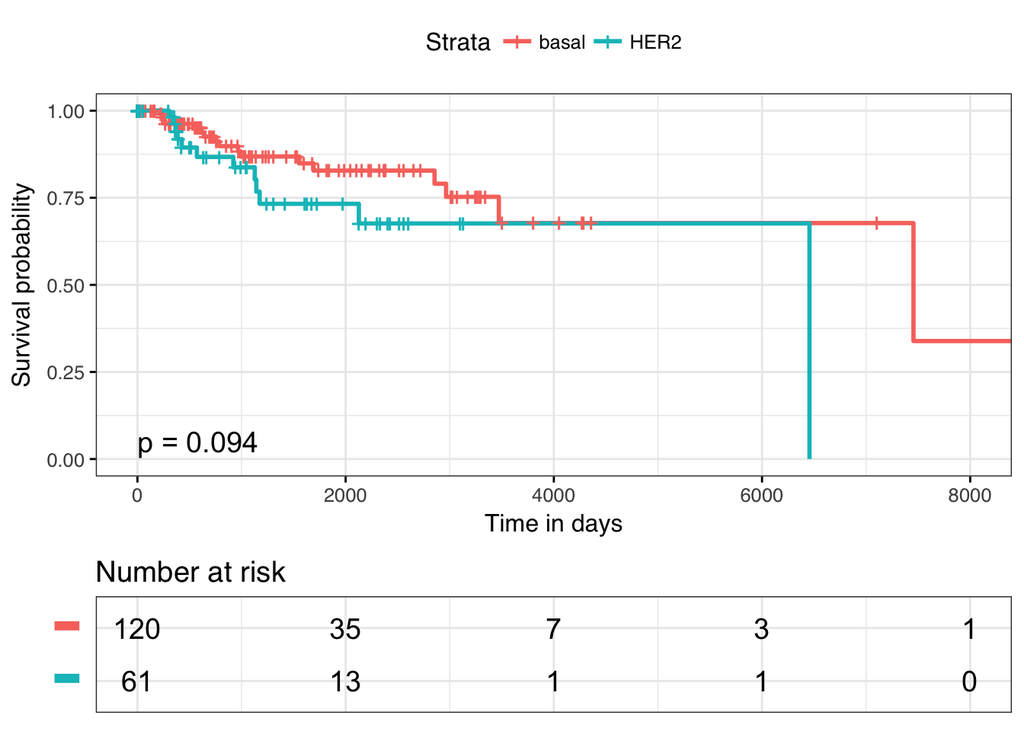

```r
Status = "OS" #modify this to change to DSS, DFI or PFI
Time = "OS.time" #modify this to change to DSS.time, DFI.time, or PFI.time


fit <- survfit(Surv(OS.time, OS) ~ group,
               data = cancerType) #This generates the survival fit for curve generation

ggsurvplot(fit, data = cancerType,
                tables.y.text = FALSE,
                tables.theme = theme_cleantable(),
                xlab = "Time in days",
                pval = T,
                pval.coord = c(0.05, 0.05),
                legend.labs = c("basal", "HER2"),
                risk.table = TRUE,
                fontsize = 5,
                ggtheme = theme_bw(base_family = "sans", base_size = 12))
```

### Hazard Ratio

To get the hazard ratio, we use the cox proportional hazard function with the same equation as above. The exp(coef), is the hazard ratio, in this instances HER2+ breast cancer is more hazardous in terms of overall survival (this is already known), with a p-value approaching significance at 0.1.

```r
coxph(Surv(OS.time, OS) ~ group,
               data = cancerType)
```

```
## Call:
## coxph(formula = Surv(OS.time, OS) ~ group, data = cancerType)
##
##            coef exp(coef) se(coef)    z   p
## groupHer2 0.639     1.894    0.388 1.65 0.1
##
## Likelihood ratio test=2.6  on 1 df, p=0.1
## n= 181, number of events= 29
```

### Survival analysis based on categorical groupings and the continous RPPA values

Here we are going to expand our survival comparison between HER2 and basal breast cancers, by adding the RPPA quantification for the estrogen receptor (ERALPHA).

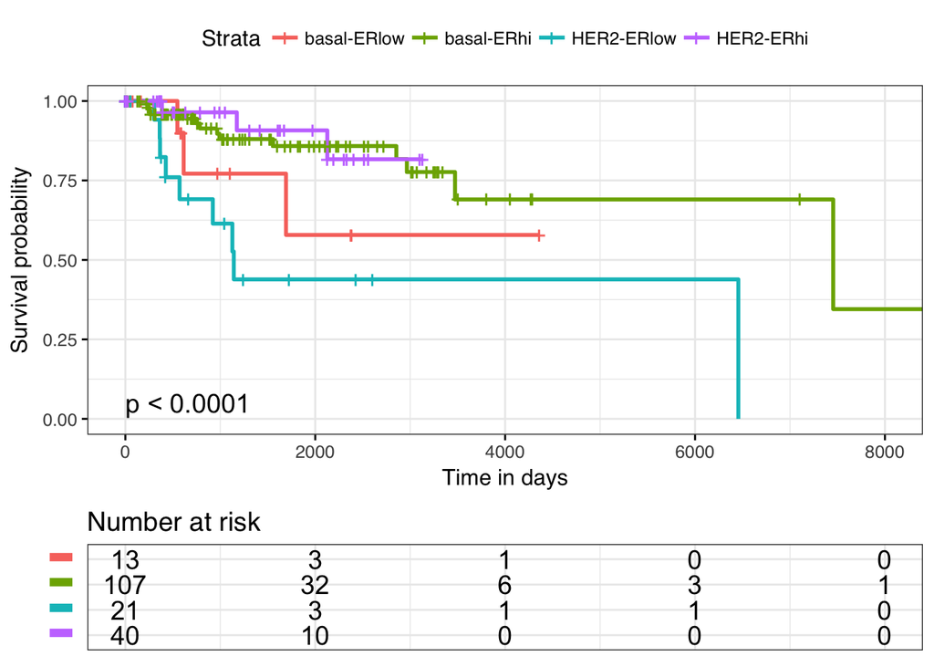

```r
cut <- surv_cutpoint(cancerType, Time, Status, variables=c("ERALPHA"), minprop = 0.15) #Optimal Cutpoint for survival

cat <- surv_categorize(cut)
cat <- cbind.data.frame(cat, cancerType$group)
colnames(cat)[4] <- "group"

fit2 <- survfit(Surv(OS.time, OS) ~group + ERALPHA,
               data = cat)

ggsurvplot(fit2, data = cancerType,
                tables.y.text = FALSE,
                tables.theme = theme_cleantable(),
                xlab = "Time in days",
                pval = T,
                pval.coord = c(0.05, 0.05),
                risk.table = TRUE,
                legend.labs = c("basal-ERlow", "basal-ERhi", "HER2-ERlow", "HER2-ERhi"),
                fontsize = 5,
                ggtheme = theme_bw(base_family = "sans", base_size = 12))
```

### Hazard Ratio

```r
coxph(Surv(OS.time, OS) ~ group + ERALPHA,
               data = cat)
```

```
## Call:
## coxph(formula = Surv(OS.time, OS) ~ group + ERALPHA, data = cat)
##
##              coef exp(coef) se(coef)     z      p
## groupHer2   0.205     1.228    0.417  0.49 0.6224
## ERALPHAlow -1.333     0.264    0.415 -3.21 0.0013
##
## Likelihood ratio test=12.02  on 2 df, p=0.002
## n= 181, number of events= 29
```

# Conclusions

Hopefully this answers some questions on quick methods to parse the TRGAted survival data to better function in your research. If you have anymore questions, feel free to email us.